# EDA: Sexism around the World

Data Science III Final Project

Irene Kwon

## Introduction

Despite the contemporary waves of feminism and women’s rights movements, sexism and gender-based oppression still persist in many parts of the world. For example, even in the modern days, more than one in four Africans see wife-beating as justifiable (Afrobarometer Survey: https://afrobarometer.org/press/more-one-four-africans-see-wife-beating-justifiable-afrobarometer-survey-finds), while more than 90% of the global population – including both men and women – is somehow biased against women (UNDP Gender Social Norms Index: https://www.undp.org/content/undp/en/home/news-centre/news/2020/Gender_Social_Norms_Index_2020.html). Yes, it is heartbreaking just to read about persistent misogyny - but to solve the problem, we have to begin by facing it directly. Therefore, for this project, I examine the following questions:

- On average, how sexist/misogynist are people around the world?
- What individual-level factors are associated with a person’s sexist/misogynistic attitudes?
- Are there meaningful differences across countries and culture in terms of sexism? Does context matter? If so, how much does it matter?

Therefore, my questions are largely *descriptive* and *predictive*. It is descriptive because I aim to present the snapshot of individuals’ attitudes toward women and girls (i.e., sexism) around the world. At the same time, the questions are predictive in that I aim to identify the most important factors to predict a person’s sexism.

In doing so, I examine both contextual and individual factors. Intuitively, we can expect that individual factors, such as (but not limited to) one’s very own gender, conservatism, religious views, or education attainment can be highly associated with one’s sexism. Simultaneously, contextual factors can matter as well; for example, culturally conservative and/or religious countries may exhibit, on average, higher degrees of sexism compared to secular and/or more liberal countries.

Note that while the results can potentially be interpreted in inferential ways (i.e., contexts matter in determining a person’s attitudes towards women – and it is highly likely that contextual factors, such as the socialization environment an individual was raised in, influenced and ultimately shaped his attitudes towards women), in this project, I do not aim at establishing a causal relationship (e.g., whether something causes a person to be misogynist).

The EDA part of the final project will proceed as follows. First, I provide a brief explanation about the data set I will be using. In this Data Overview section, I will also lay out potential issues regarding the data set and how I aim to handle them.

Then I advance to the actual exploration of the dataset. This section will focus on exploring the distribution of the variables in the dataset, and how the variables are associated with each other. As such, the Exploration Section will shape our initial priors about the findings to expect from the actual Data Analysis Report. Lastly, I conclude the EDA report by summarizing the findings from the exploration.

## Data Overview

I aim to use the World Values Survey (WVS) to ansewr the guiding questions mentioned above.

### 1. Data Explanation & Why this Data?

The WVS is a worldwide investigation of sociocultural and political change, and focus mainly on values of respondents – e.g., mainly on political, gender, and economic attitudes (Inglehart et al. 2004). It covers countries from all parts of the world – from Asia to Africa. With the same questionnaire (translated in different languages), the Survey enables cross-country, over-time comparisons. The questionnaire includes a wide range of items asking the basic demographics, and those about values regarding gender (broadly construed), family, religion, and politics. Therefore, to identify which factors - both individual and country level - predict a person’s attitudes toward gender issues, the WVS will provide very insightful data.

While the WVS has had multiple rounds (i.e., waves) so far, starting from 1981, I limit the scope of analysis to the 6th wave only. The 6th wave is the most recent wave completed as of now, with the 7th wave being done right now. As I state below, this is because each wave contains slightly different questions especially those on sexism, making it hard to construct a variable that enables across-time comparisons.

Data citation: Inglehart, R., C. Haerpfer, A. Moreno, C. Welzel, K. Kizilova, J. Diez-Medrano, M. Lagos, P. Norris, E. Ponarin & B. Puranen et al. (eds.). 2014. World Values Survey: All Rounds - Country-Pooled Datafile Version: http://www.worldvaluessurvey.org/WVSDocumentationWVL.jsp. Madrid: JD Systems Institute.

### 2. Missingness

Since this is a survey data, people can simply choose not to answer, or respond that they do not know - and indeed, there were a bunch of “don’t know”s and “no answer”s. In the original dataset, these responses were coded to have negative values (e.g., -1 for don’t know, -2 for no answer, -4 for not asked in the survey, etc.). To facilitate the data analysis, I just coded the values less than 0 coded as missing (`NA`). Of course, simply choosing not to answer and reponding with “don’t know” can substantively mean something, but without clear theoretical reasons, assigning these responses with some numerical values (for the analysis) may skew and distort the conclusion of our analysis even more.

The following plot looks at the missing values for the entire data set to be used (rather than the split set for the EDA - I discuss more on the data split below).

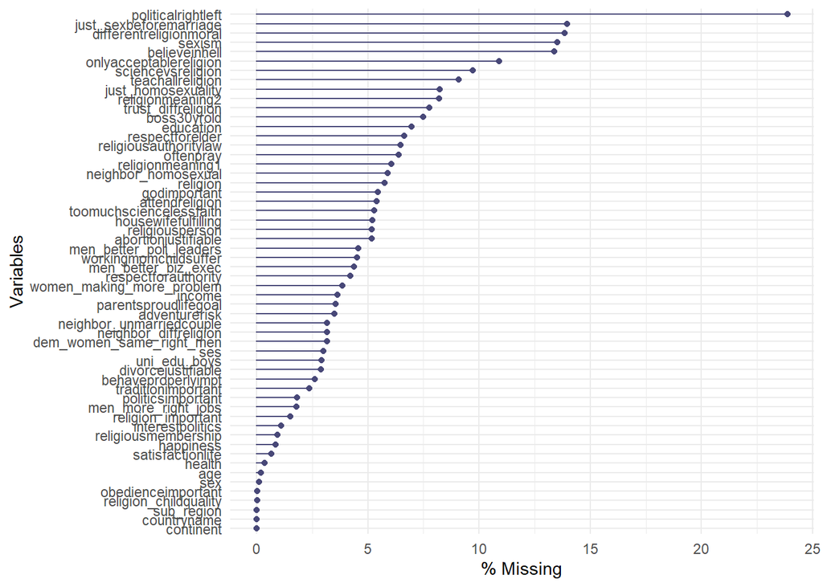

As can be seen, the variable with the most missing values is an individual’s self-positioning on the political left-right scale. It has about 25% of the missingness. I noticed that some countries had higher proportion of respondents who answered “they do not know”, or simply did not answer to the question. For example, in Yemen, about 67% of the respondents chose “do not know” as their answers to the political self-positioning question; about 59% of the respondents from Uzbekistan did not even answer to this question. From this, we can conjecture that the missingness may probably due to the regime type (an exception would be Japan; 27.5% of the respondents said they “do not know”, although Japan is an established democracy).

The questions which had the second most missingness are (1) whether sex before marriage is justifiable, and (2) whether the respondents believe that people of different religions are as moral as they are. To these questions, the country-specific pattern(s) do(es) not emerge - that is, the question itself does not have political implications as it is more of value-related, moral question. Most other variables have less than 10% missing entries - which is not negligible, but not to the extent that is is tremendously concerning.

In the analysis (at least for the EDA), I just choose to drop the missing values. It is true that there may be some systematic variations in the missigness structure, and it may somehow affect our analysis - however, without substantive knowledge and well-established theories about how to interpret “no answer” and “don’t know” (which is, by itself, a very interesting and meaningful social science research question), it may as well affect and skew our analysis if we just replace them with some other values (such as through the multiply imputed values, means or median).

### 3. Data Split

Per protocol, I split the data set into three parts, and use different data sets for the EDA, training the model and validating/testing the model. I assign 20% of the entire dataset for the EDA, 60% for model building, and the remaining 20% for testing the candidate models.

One thing to note about the WVS data set is the structure of the data set. Since the same survey is conducted in different countries, and since the survey concerns individuals, the data set has a hierarchical (or nested) structure. This can be an issue when splitting the data into three different sets; we do not want covariate imbalance - e.g., we do not want observations from the U.S. to be mostly in the training set while we have only couple observations from Thailand in the training set.

Theoretically, random split should take care of covariate imbalance (since all the individuals have the same probability of being assigned to one group over another). Therefore, I first try out the random split - if it seems that the three sets are relatively well balanced, the I just proceed using the randomly split dataset.

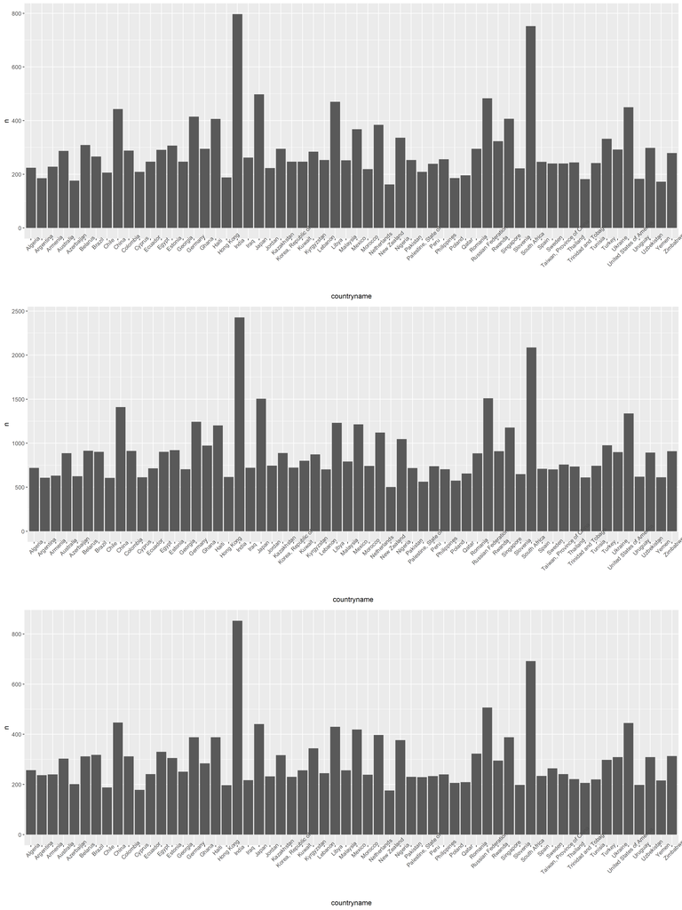

It looks like the distributions of the countries are relatively well balanced across all three splits - i.e., the histograms have similar shapes. It seems that it would be okay to use the split data sets as such. Therefore, I proceed to the EDA with the EDA portion of the dataset.

### 4. Data Prep

Finally, to make the data analysis (as well as data exploration) easier, I “tidied up” the dataset. First, the country variable was coded in numeric values (in ISO country codes), not in character/factors. I re-coded the country variable so that it now has country names corresponding to the three-digit country codes. I also added the continent and regional variables using the following dataset (https://datahub.io/JohnSnowLabs/country-and-continent-codes-list). Finally, as stated before, the WVS is a time-series, cross-sectional (i.e., panel) dataset. However, (1) each wave has different sets of questions, and (2) it makes sense to place “more weight” on more current information. Hence I just use the 6th wave, the latest wave of the survey (the seventh wave is currently undergoing!).

## Exploration of the Data

Putting my political scientist hat on, the following parts of this EDA report are mainly motivated by my social-sciency comparative perspective. But first, I begin by skimming the entire dataset.

Data summary

| Name | Piped data |
| --- | --- |
| Number of rows | 17735 |
| Number of columns | 56 |
| _______________________ |  |
| Column type frequency: |  |
| character | 3 |
| factor | 1 |
| numeric | 52 |
| ________________________ |  |
| Group variables | None |

**Variable type: character**

| skim_variable | n_missing | complete_rate | min | max | empty | n_unique | whitespace |
| --- | --- | --- | --- | --- | --- | --- | --- |
| countryname | 0 | 1 | 4 | 25 | 0 | 60 | 0 |
| continent | 0 | 1 | 4 | 8 | 0 | 5 | 0 |
| sub_region | 0 | 1 | 9 | 25 | 0 | 18 | 0 |

**Variable type: factor**

| skim_variable | n_missing | complete_rate | ordered | n_unique | top_counts |
| --- | --- | --- | --- | --- | --- |
| religion | 991 | 0.94 | FALSE | 55 | 49: 3571, 0: 3219, 64: 2967, 52: 1592 |

**Variable type: numeric**

| skim_variable | n_missing | complete_rate | mean | sd | p0 | p25 | p50 | p75 | p100 |
| --- | --- | --- | --- | --- | --- | --- | --- | --- | --- |
| sex | 14 | 1.00 | 1.52 | 0.50 | 1 | 1 | 2 | 2 | 2 |
| age | 32 | 1.00 | 42.14 | 16.60 | 16 | 28 | 40 | 54 | 99 |
| education | 1157 | 0.93 | 4.94 | 2.18 | 1 | 3 | 5 | 7 | 8 |
| ses | 519 | 0.97 | 3.31 | 1.00 | 1 | 3 | 3 | 4 | 5 |
| income | 647 | 0.96 | 4.85 | 2.12 | 1 | 3 | 5 | 6 | 10 |
| religion_important | 261 | 0.99 | 1.89 | 1.05 | 1 | 1 | 2 | 3 | 4 |
| religion_childquality | 5 | 1.00 | 0.41 | 0.49 | 0 | 0 | 0 | 1 | 1 |
| religiousmembership | 150 | 0.99 | 0.51 | 0.78 | 0 | 0 | 0 | 1 | 2 |
| attendreligion | 896 | 0.95 | 4.52 | 2.63 | 1 | 2 | 4 | 7 | 8 |
| oftenpray | 1089 | 0.94 | 3.71 | 2.70 | 1 | 1 | 3 | 7 | 8 |
| religiousperson | 912 | 0.95 | 1.38 | 0.59 | 1 | 1 | 1 | 2 | 3 |
| religionmeaning1 | 1059 | 0.94 | 1.71 | 0.56 | 1 | 1 | 2 | 2 | 4 |
| religionmeaning2 | 1465 | 0.92 | 1.72 | 0.57 | 1 | 1 | 2 | 2 | 4 |
| sciencevsreligion | 1711 | 0.90 | 2.39 | 1.08 | 1 | 1 | 2 | 3 | 4 |
| onlyacceptablereligion | 1972 | 0.89 | 2.46 | 1.09 | 1 | 1 | 3 | 3 | 4 |
| teachallreligion | 1627 | 0.91 | 2.55 | 1.01 | 1 | 2 | 3 | 3 | 4 |
| differentreligionmoral | 2451 | 0.86 | 2.14 | 0.88 | 1 | 2 | 2 | 3 | 4 |
| religiousauthoritylaw | 1117 | 0.94 | 4.22 | 2.96 | 1 | 1 | 4 | 6 | 10 |
| neighbor_diffreligion | 539 | 0.97 | 0.19 | 0.40 | 0 | 0 | 0 | 0 | 1 |
| trust_diffreligion | 1397 | 0.92 | 2.77 | 0.87 | 1 | 2 | 3 | 3 | 4 |
| toomuchsciencelessfaith | 909 | 0.95 | 5.46 | 2.82 | 1 | 3 | 5 | 8 | 10 |
| just_sexbeforemarriage | 2440 | 0.86 | 4.56 | 3.36 | 1 | 1 | 4 | 8 | 10 |
| neighbor_unmarriedcouple | 541 | 0.97 | 0.27 | 0.44 | 0 | 0 | 0 | 1 | 1 |
| just_homosexuality | 1415 | 0.92 | 3.29 | 3.04 | 1 | 1 | 1 | 5 | 10 |
| neighbor_homosexual | 1039 | 0.94 | 0.51 | 0.50 | 0 | 0 | 1 | 1 | 1 |
| traditionimportant | 396 | 0.98 | 2.52 | 1.43 | 1 | 1 | 2 | 3 | 6 |
| workingmomchildsuffer | 779 | 0.96 | 2.51 | 0.93 | 1 | 2 | 2 | 3 | 4 |
| divorcejustifiable | 487 | 0.97 | 4.59 | 3.10 | 1 | 1 | 5 | 7 | 10 |
| parentsproudlifegoal | 634 | 0.96 | 1.65 | 0.75 | 1 | 1 | 2 | 2 | 4 |
| housewifefulfilling | 907 | 0.95 | 2.21 | 0.94 | 1 | 1 | 2 | 3 | 4 |
| adventurerisk | 605 | 0.97 | 3.73 | 1.61 | 1 | 2 | 4 | 5 | 6 |
| behaveproperlyimpt | 462 | 0.97 | 2.54 | 1.36 | 1 | 1 | 2 | 3 | 6 |
| abortionjustifiable | 900 | 0.95 | 3.25 | 2.77 | 1 | 1 | 2 | 5 | 10 |
| politicsimportant | 311 | 0.98 | 2.62 | 0.98 | 1 | 2 | 3 | 3 | 4 |
| interestpolitics | 205 | 0.99 | 2.63 | 0.98 | 1 | 2 | 3 | 3 | 4 |
| politicalrightleft | 4171 | 0.76 | 5.66 | 2.36 | 1 | 5 | 5 | 7 | 10 |
| happiness | 143 | 0.99 | 1.85 | 0.74 | 1 | 1 | 2 | 2 | 4 |
| health | 71 | 1.00 | 2.09 | 0.85 | 1 | 1 | 2 | 3 | 4 |
| satisfactionlife | 116 | 0.99 | 6.83 | 2.28 | 1 | 5 | 7 | 8 | 10 |
| men_more_right_jobs | 308 | 0.98 | 1.98 | 0.90 | 1 | 1 | 2 | 3 | 3 |
| women_making_more_problem | 664 | 0.96 | 2.03 | 0.77 | 1 | 1 | 2 | 3 | 3 |
| men_better_poli_leaders | 819 | 0.95 | 2.59 | 1.00 | 1 | 2 | 3 | 3 | 4 |
| men_better_biz_exec | 767 | 0.96 | 2.45 | 1.00 | 1 | 2 | 2 | 3 | 4 |
| uni_edu_boys | 505 | 0.97 | 2.07 | 0.94 | 1 | 1 | 2 | 3 | 4 |
| dem_women_same_right_men | 523 | 0.97 | 3.11 | 2.58 | 1 | 1 | 2 | 5 | 10 |
| sexism | 2375 | 0.87 | 16.78 | 4.89 | 7 | 13 | 16 | 20 | 32 |
| respectforelder | 1146 | 0.94 | 2.33 | 0.91 | 1 | 2 | 2 | 3 | 4 |
| respectforauthority | 729 | 0.96 | 1.50 | 0.70 | 1 | 1 | 1 | 2 | 3 |
| obedienceimportant | 5 | 1.00 | 0.42 | 0.49 | 0 | 0 | 0 | 1 | 1 |
| boss30yrold | 1288 | 0.93 | 6.92 | 2.45 | 1 | 5 | 7 | 9 | 10 |
| believeinhell | 2340 | 0.87 | 0.62 | 0.49 | 0 | 0 | 1 | 1 | 1 |
| godimportant | 943 | 0.95 | 7.71 | 2.99 | 1 | 6 | 9 | 10 | 10 |

### 1. Dependent Variable

First, to create an index of how much sexist a person is, I re-code some relevant variables and combined them to create a single numerical score such that **higher values indicate higher sexism**. Specifically, I combined the responses to the following seven questions:

1. When jobs are scarce, whether men should have more right to a job than women.
2. How much respondents agree or disagree with the given statement: men make better political leaders than women do.
3. How much respondents agree or disagree with the given statement: men make better business executives than women do.
4. How much respondents agree or disagree with the given statement: whether university education is more important for a boy than for a girl.
5. How much respondents agree or disagree with the given statement: if a woman earns more money than her husband, it is almost certain to cause a problem.
6. How much respondents agree or disagree with the given statement: if their mothers work, children suffer.
7. Whether the following statement is an essential characteristic of democracy: women have the same right as men.

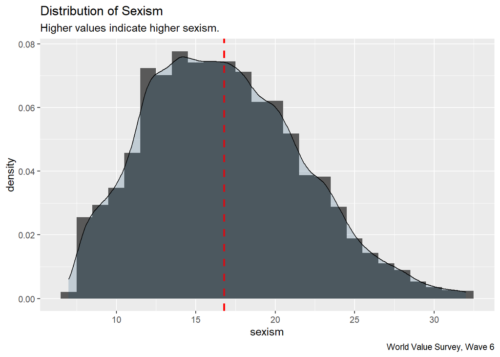

As can be seen, the combined score variable `sexism` ranges from 7 (the least sexism) to 32 (the highest sexism). It has a long right tail, with the mode being 14 (with 1193 respondents). The red dashed line in the middle denotes the mean of the sexism score. Most of the answers are located between 12 and 18.

Next, to understand the dependent variable better, I now take a look at (1) how (much) the constituent variables are correlated with each other, and (2) what variable(s) explain most of the variations in the sexism.

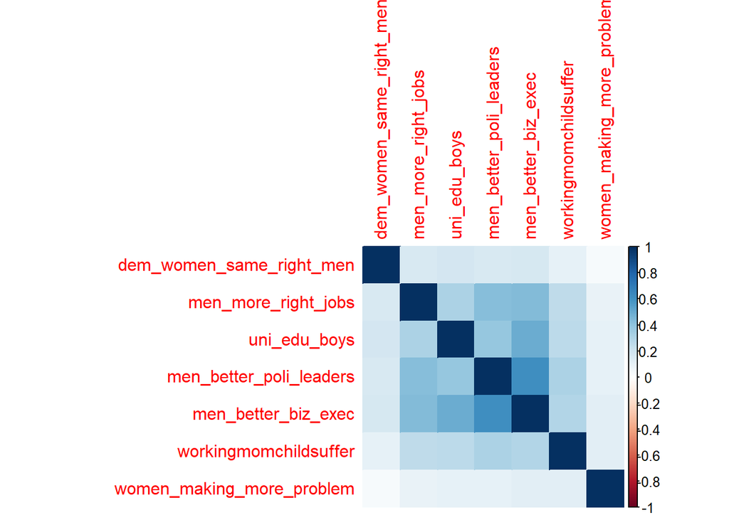

First, as can be seen from the correlation heatmap above, there are mild to moderate correlations between the constituting variables. Though I do have to admit that the sexism score I constructed is not necessarily based on thoroughly researched, theoretically sound grounds, I do not think this set of mild to moderate correlation between constituents would cast doubt on the validity of the response variable I will be using.

This is because each question may indicate different faces of sexism. Also, individuals might be unconsciously be sexist - take my parents, for example. They argue that they are not sexists (although I do believe that unfortunately, they are quite sexists) - after all, they have two daughters only. My dad genuinely believes that men make better business leaders than women, and men are more suited for political positions because of their “masculinity”. At the same time, though, he also believes that university education is also very important for women.

Additionally, I also look at what variable(s) is(are) most reponsible for explaining the variation in the `sexism` variable. I use principal component analysis (PCA) for this:

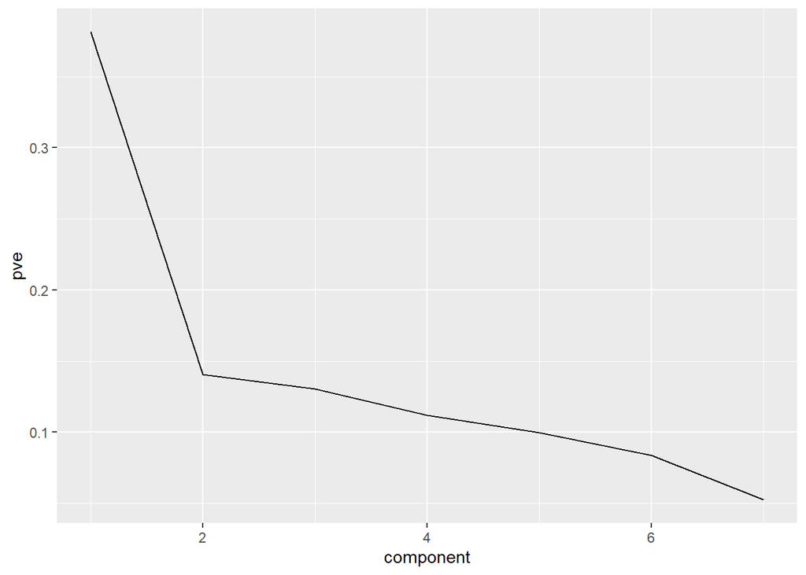

### 2. Distribution of Demographic Variables

Next, I graphically present the distribution of the major demographic variables: age, sex, education attainment, and self-reported (i.e., subjective) socioeconomic class of respondents.

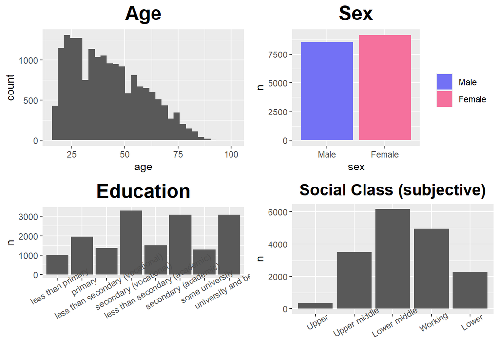

### 3. Relational Distribution

As the next part of the EDA, I explore how the variables are associated with each other. Given that this is a survey asking about respondents’ attitudes about given issues, most of the variables are not continuous - that is, they are not granular enough. Therefore, scatterplots proved to be not very insighful for the EDA. Therefore, I mainly present boxplots for this section.

**1. Distribution of Sexism by (sub)region**

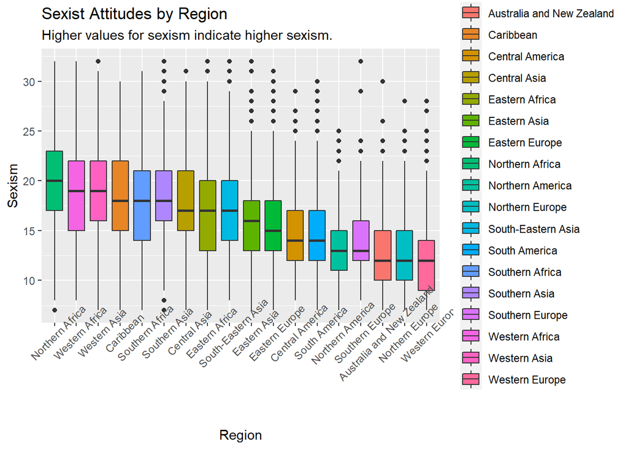

As we can see, there is quite a gap between the most sexist region (on average) and the least sexist region (on average). People in the Northern Africa are much more sexist than people in Western Europe. Of course, outliers do exist - in Northern Africa, there are people with almost no sexism at all (denoted by the dot under the box and the whiskers); in Western Europe, there are some outliersas well, who are more sexist than an average North African. However, the main message of the plot definitely confirms our prior - that there is a very clear difference in average people’s sexist attitudes across region.

**2. Distribution of Sexism by Gender**

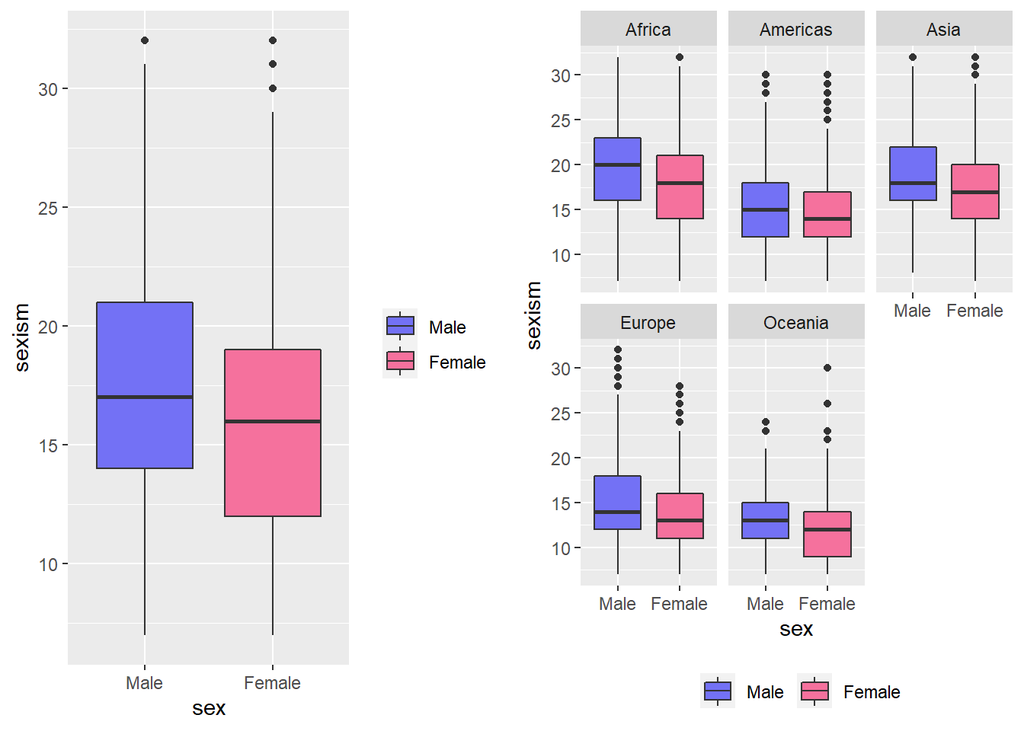

As we can expect, men are in general more sexist than women; moreover, such difference in means exist in almost all continents. We can see that the gap is wider in Africa, where everyone is more sexist on average than in other coninents, and the gender gap is smaller in Americas. But the main message is that women - with their long history of being oppressed and violated - are generally less sexist across all cultures.

**3. Distribution of Sexism by Educational Level**

Another factor that may affect one’s sexist attitudes would be his/her education. Specifically, I expect that university education may matter a lot in shaping someone’s sexist attitudes. University environments tend to be liberal, and as institutes for higher education, they teach students tolerance, social justice and progressive norms as well (Hainmueller and Hiscox 2006). Therefore, probably people with tertiary education might have less sexism and prejudice against women.

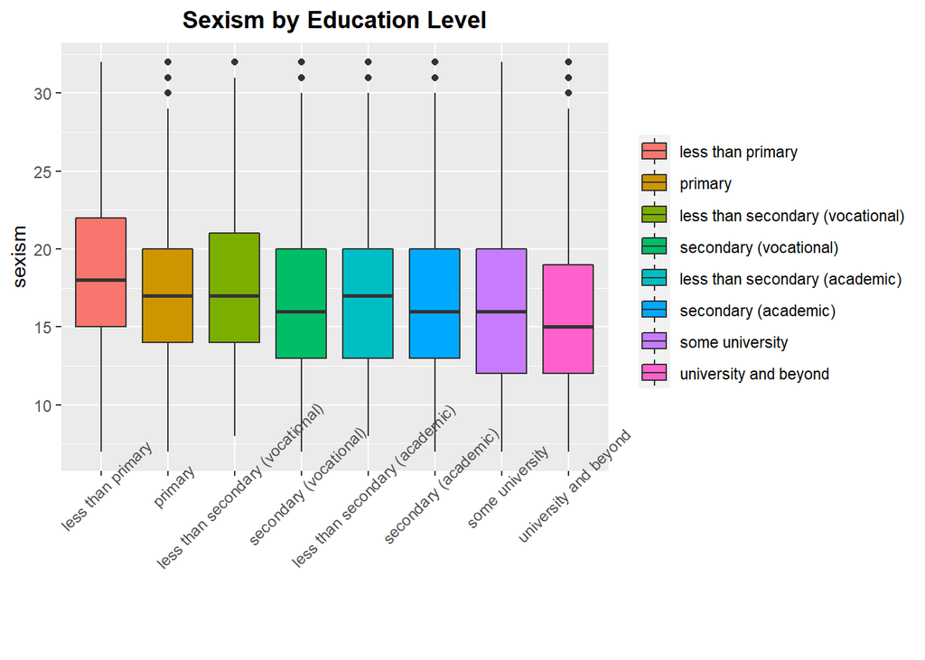

To my dissapointment, there was not so much difference between one’s education level and his/her sexist attitudes. We can see that compared with those who did not finish primary education, people who have received university education has less sexism, but the difference is not remarkable. I now break it down by region:

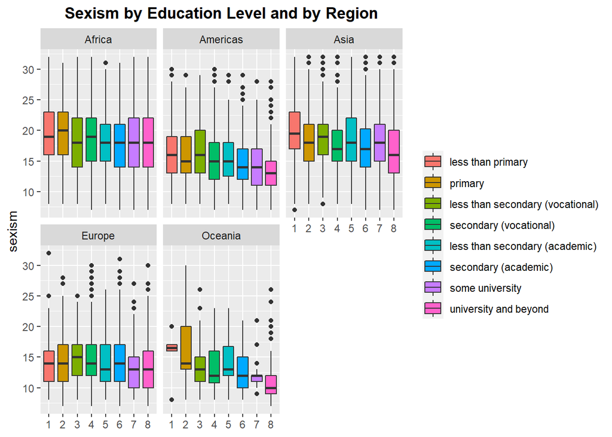

It provide a more constructive picture than the previous plot. First, in general, education now seems to matter - especially in Americas, Asia, and Oceania. In Africa, where respondents in general showed higher degree of sexism than their counterparts in other regions, education does not seem to matter much. Similarly, in European as well, education did not seem to matter much either. In other parts of the world, though, education did contribute to somewhat lowering sexism.

Then does education have some kind of “interaction effects” with a person’s gender?

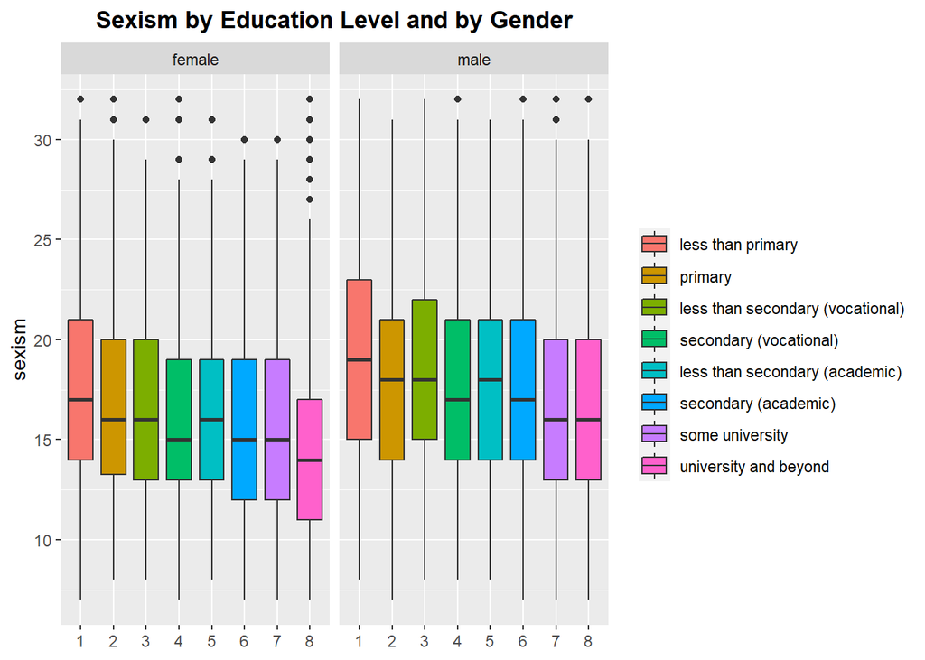

In general, women are again less “sexist” than men (for all education levels). Additionally, as we can expect, college-educated female had the most liberal gender attitudes, while male with the least eucation was the most sexist - again confirming the “education hypothesis”. The practical, normative implication would be that not only are educating girls and paving ways for their higher education the way to go, but men also have to learn more.

**4. Distribution of Sexism by Age Group**

Next, I explore how age is associated with one’s sexist attitudes. My priors state that the older people are, the more conservative they are - therefore, they may subscribe to more traditional gender norms. Then, we should be able to witness a correlation between age and sexist attitudes. Spoiler alert - the sexism score did not differ a lot across age groups.

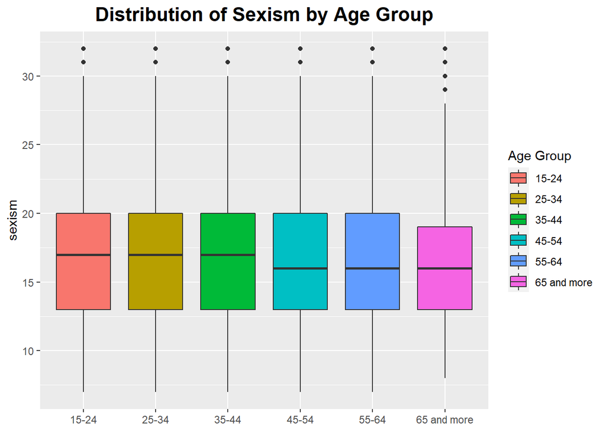

Even if we break it down by the continents, we do not see drastically different results. It seems that age groups are not substantially correlated with sexist attitudes. This is so surprising! So agai, I broke it down by region:

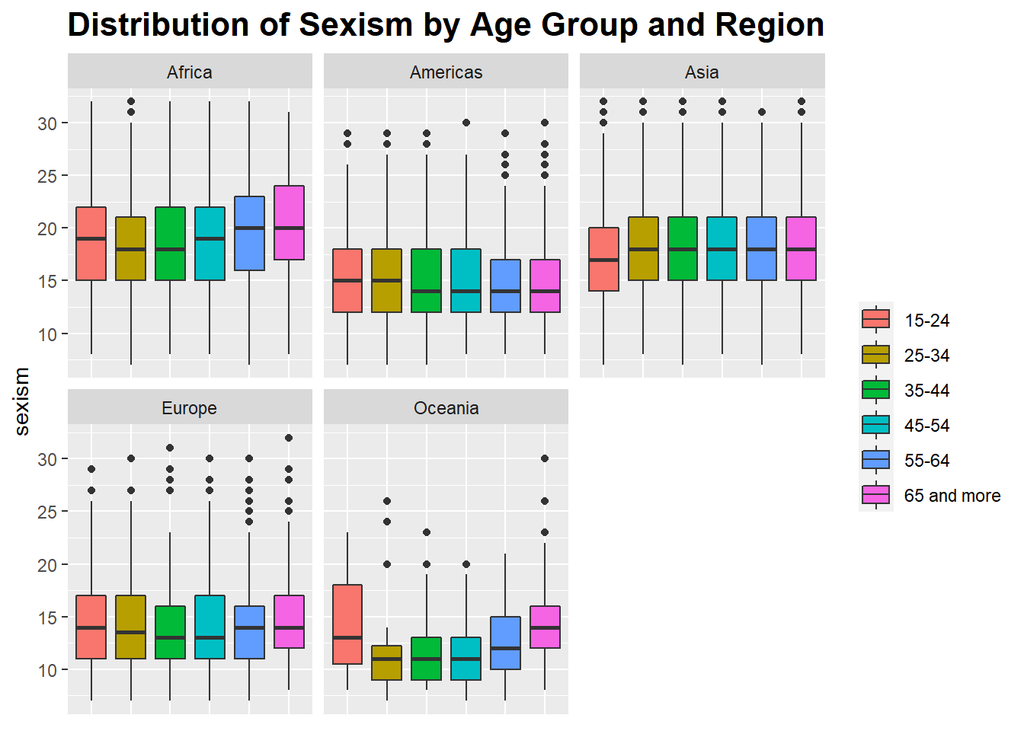

Again, we do not see substantial differences across age groups. Of course, people tend to lean more towards greater sexism in Africa and in Europe, but the trend is negligible. Moreover, in Oceania, younger people are more sexist than other age groups (except those whoare 65 and more).

I can think of potential reasons which may account for this counterintuitive finding. First, age may not really matter. Second, the age group classification is too rough (I followed the WVS’s guideline to group the age cohorts). Lastly, age matters only through interacting with other variables, such as gender and education level.

**5. Distribution of Sexism by Religiosity**

Another factor that may strongly contribute to sexism would be religion. Religion is often associated with conservatism; it prescribes traditional gender roles and norms, hence normalizing sexism and gender-based oppression.

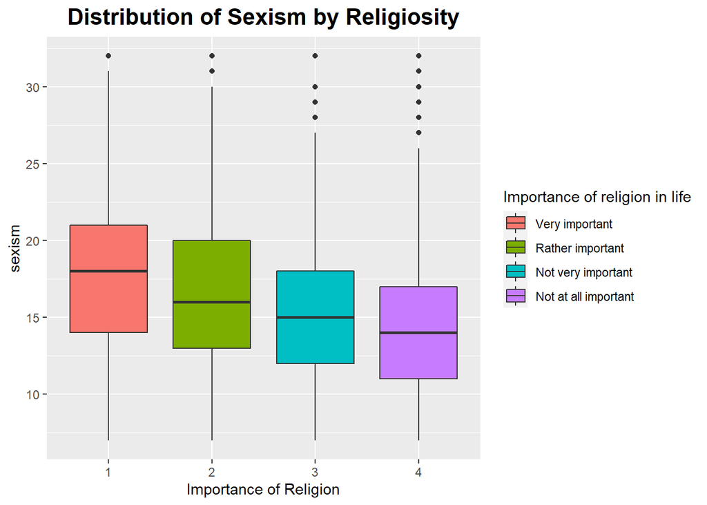

The more important role religion plays in a person’s life, the more sexist he/she is (on average).

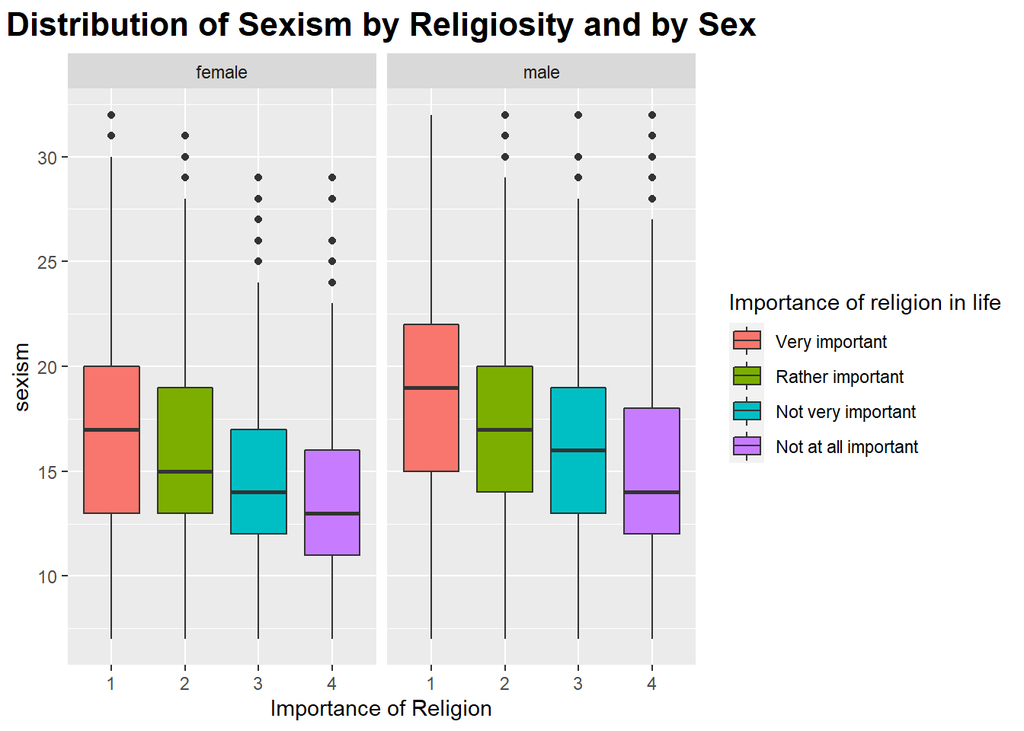

The difference is even larger for male. That is, if a man feels that religion is very important in his life, he is significantly likely to be more sexist that a man who believes that religion is not at all important in his life.

**6. Distribution of Sexism by Political Leanings**

At least in the United States, partisanship and political left-right ideology seem to affect how one feels about women and sexism. Liberals are less sexist, while conservatives are more sexist - though unknowingly (like my dad, for example. He is a strong conservative and a strong Republican, but he geniunely doesn’t believe that he is sexist).

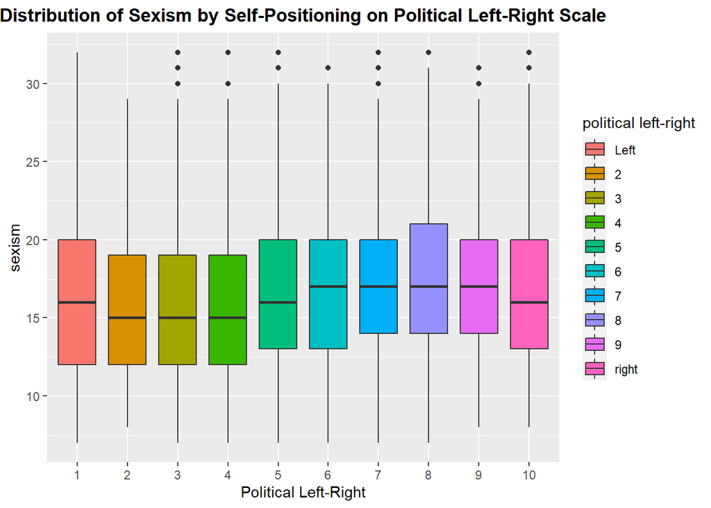

According to the boxplots above, it seems that self-positioning on political left-right scale does not translate into one’s sexist attitudes. I expected a “rising” trend, as smaller numbers on the X-axis indicate more liberalism and higher numbers more conservatism.

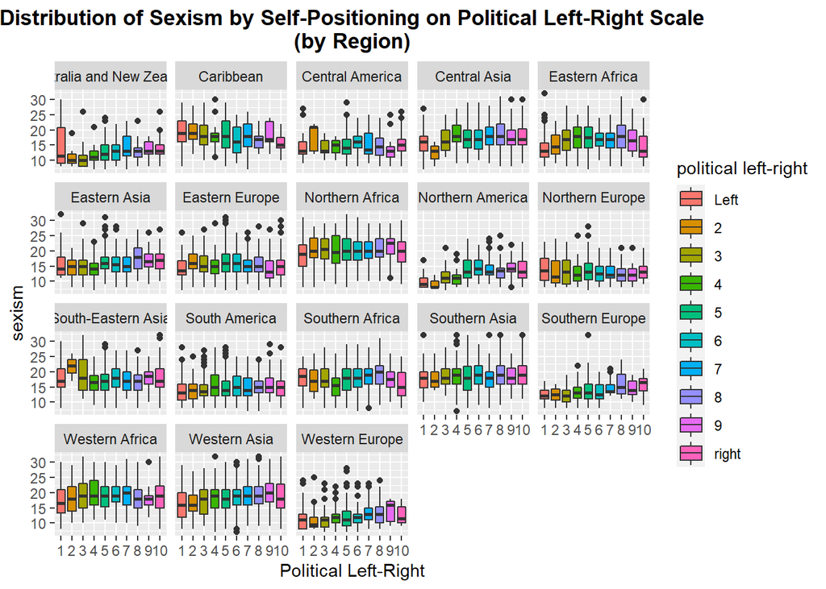

This figure is more constructive - understandably so! What it means to be politically left in South Korea may mean something different than what it means to be politically left in the United States.

English-speaking, Anglo-Saxon countries - Australia and New Zealand and Northern America - show what I anticipated to find: the more politically right a person is, the higher sexist attitude he/she has. European countries - Southern and Western - show similar tendency; while Northwern and Eastern Europe do not exhibit as clear a pattern. The distribution of sexism in more traditional/conservative societies like Africa does not have a partisan pattern - in fact, in Eastern Africa, the distribution of average sexism score has an inverse-U curve: people in the center are the most sexist (as opposed to people in the far right or far left).

Probably this may mean that the interpretation of political right/left may be different from society to society; being “political right” may entail different social norms and policy preferences in different contexts. Or, political leanings may be an important determinant in shaping a person’s sexist attitudes in some cultures (e.g., in North America) while not being necessarily so in others (e.g., Eastern Europe).

**7. Heatmaps (correlation plots): how sexism score is associated with select variables**

Lastly, I look at the correlation between one’s personal beliefs: authoritarian personality traits, social conservatism, traditional values, and religiosity. These are all the factors that one can assume to have some association with a person’s sexism.

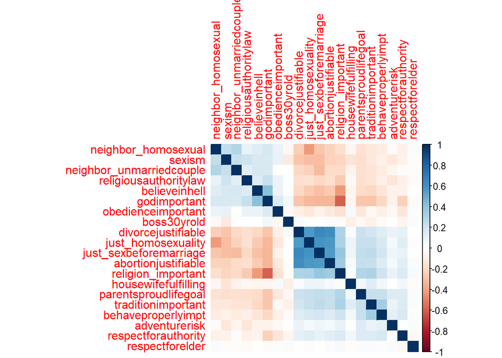

Please note that I did not re-code these variables such that high values indicate placing more importance to tradition and/or religion. That is, negative numerical correlations can actually mean positive substantive correlation.

First, we can see a chunk of stronger correlation between `divorcejustifiable`, `just_homosexuality`, `just_sexbeforemarriage`, `abortionjustifiable`, and `religion_important`. These variables have moderate correlation with `sexism` as well. It means that those who have conservative attitudes towards sex and sexuality are also likely to hold more sexist views.

## Tentative Conclusion

One caveat to note is that I used gender and sex somewhat interchangeably in this study, but I do acknowledge that gender in and of itself can be a somewhat fluid concept. The reason I used it somewhat interchangeably is that the WVS itself did not distinguish the two clearly + when we talk about sexism, our focus is relatively on the biological sex (and the gender norms derived from it). But this is not to say that I am ignorant of, or even disapproving of, the non-gender binary folks - in fact, I am a strong supporter of LGBTQ+ community!

The exploratory data analysis does confirm some of our priors. First, we do see the graphical evidence that context does matter: African countries, for example, exhibit much higher sexism than Northern/Western European countries on average. Furthermore, the gap between two genders are wider in Africa and smaller in Americas or in Oceania. I suspect that this is not because men there are inherently “better”, but because their cultural and social norms prescribe that both genders are equal. Therefore, *both* men and women are accustomed to not attributing certain roles and traits to certain gender.

Second, as I suspected, religiosity was indeed associated with one’s sexist attitudes. Those who believe that religion plays a very important role in their lives were more likely to have antiquated gender norms - i.e., more sexism. Not to say that religion is evil and we should all be atheists or antagonists, but to point out that religion does contribute!

Third, gender matters. Let’s face the truth: gender-based violence and female oppression have taken place everywhere, in every time period. It seems that women are somewhat cognizant of that fact, and they have less sexism against themselves. Across all continents and sub-regions, women turned out to be less sexist than men.

Lastly, the exploratory data analysis with education provided a potential solution to sexism. Indeed, in some societies, the effect of education was not as prominent, but in other societies, higher education was indeed associated with lower sexism for both men and women. Educating girls is not enough - We need boys to be educated as well!

In the Final Report, I will present a more systematic exploration of the data. Using the models we covered in class - e.g., clustering, CART, Lasso, etc. - I aim to identify which factors matter the most in predicting one’s sexist attitudes.